# Time Series Analysis on e-Commerce Data to Predict the Price of a Product in FUTURE

# Problem Description

Using e-commerce data, build time series models to predict the price of a certain product 4 weeks in advance. And finally evaluate each of the algorithms.

### Clear the Global Environment

```r
rm(list=ls(all=TRUE))
```

### Load required R library

```r
library(zoo)
library(dplyr)
library(TTR)
library(forecast)
library(DMwR)
#library(data.table)
```

### Read Data from RData

- Set current working directory
- Use readRDS function to read RData file

```r
#setwd("/home/Desktop/TS")

data = readRDS("ecommerceData.RData")
```

### Explore and understand the data

```r
## Dimension of the Data set
dim(data)
```

```
## [1] 3316190       6
```

```r
## Look at the summary statistics
summary(data)
```

```
##       V1               TitleKey           Price            Quantity
##  Length:3316190     Min.   : 221205   Min.   :   0.01   Min.   :  1.00
##  Class :character   1st Qu.:1561944   1st Qu.:  63.97   1st Qu.:  1.00
##  Mode  :character   Median :4302628   Median :  86.85   Median :  1.00
##                     Mean   :4407778   Mean   :  91.82   Mean   : 30.77
##                     3rd Qu.:6989428   3rd Qu.: 113.93   3rd Qu.:  3.00
##                     Max.   :9186772   Max.   :2545.21   Max.   :999.00
##   Condition             Date
##  Length:3316190     Length:3316190
##  Class :character   Class :character
##  Mode  :character   Mode  :character
##
##
##
```

```r
## As it is not very clearn, lets look at the first and last 10 records using head and tail commands
head(data, 10)
```

```
##    V1 TitleKey  Price Quantity Condition       Date
## 1   1  8374241  73.40        1       New 2009-06-01
## 2   2  6252362 108.00        1 Very Good 2009-06-01
## 3   3  8049481 111.02        1      Mint 2009-06-01
## 4   4  6399602 127.80        1      Mint 2009-06-01
## 5   5  1091846 118.00        1       New 2009-06-01
## 6   6  1198056  44.90        1      Mint 2009-06-01
## 7   7  1532705  84.15        4       New 2009-06-01
## 8   8  1118812  82.89       41       New 2009-06-01
## 9   9  1123511  71.80        2      Good 2009-06-01
## 10 10  4690721  50.00        1      Good 2009-06-01
```

```r
tail(data, 10)
```

```
##              V1 TitleKey  Price Quantity  Condition       Date
## 3316181 3316181  2873279  49.95        1       Good 2013-08-09
## 3316182 3316182  2231521  48.98        1        New 2013-08-09
## 3316183 3316183  1018776  50.00        1       Mint 2013-08-09
## 3316184 3316184  8977907 114.42        1 Acceptable 2013-08-09
## 3316185 3316185   490823 105.95        1        New 2013-08-09
## 3316186 3316186  8768865  63.91        1       Mint 2013-08-09
## 3316187 3316187  2808755 112.86        1       Good 2013-08-09
## 3316188 3316188  3120432 149.95        1 Acceptable 2013-08-09
## 3316189 3316189  1462143 149.76        4        New 2013-08-09
## 3316190 3316190  6399602  60.00        1       Good 2013-08-09
```

```r
## Look into Condition attribute
table(data$Condition)
```

```
##
## Acceptable       Good       Mint        New  Very Good
##     284251     778239     280389    1593241     380070
```

```r
## Look into Titlekey attribute
table(data$TitleKey)
```

```
##
##  221205  273693  315169  367034  432113  433756  490823  506270  842501
##   32051   31991   32866   32574   32699   31663   32820   32597   32561
##  879967 1018776 1091846 1118812 1123511 1138845 1140553 1198056 1205266
##   32724   33243   32307   32454   32217   30684   32359   33702   32870
## 1288607 1462143 1464896 1515222 1523071 1532705 1541863 1561944 1619727
##   31814   31199   32598   32661   33088   32136   33188   31879   32614
## 1644625 1707665 1752438 2096577 2231521 2422979 2437264 2443602 2446225
##   20176   32729   32794   31656   32727   32698   26246   32420   32333
## 2450811 2451420 2660657 2773679 2808755 2871259 2873279 3019001 3119793
##   33052   32394   34068   29268   32905   32422   32431   32318   32415
## 3120432 3121347 3128336 3128938 4283861 4289323 4302628 4389202 4456969
##   32534   33361   32565   31071   33981   32555   33807   32563   31470
## 4505684 4511602 4676989 4687744 4688228 4690721 4702308 4705669 4730066
##   32194   32530   31951   32336   32509   32344   32884   32940   32566
## 4735628 4770054 4793422 4862728 5124701 5294728 5724329 6252362 6254632
##   26243   32601   32161   16454   32260   32343   29561   31273   32672
## 6399602 6485311 6760671 6871280 6896787 6915669 6989428 8044330 8045088
##   31525   29305   28499   30498   32065   31715   29433   31558   31633
## 8046315 8046648 8046762 8048046 8049481 8050017 8366789 8374241 8768865
##   29719   29578   30837   30827   31212   30522   29475   33082   28739
## 8772755 8778959 8787038 8799748 8830516 8896060 8944101 8946697 8973539
##   32956   28705   27884   30325   28957   26103   28412   25816   28363
## 8977907 9000092 9010840 9062282 9078964 9117389 9149582 9186772
##   27366   27926   28191   26821   27455   26095   25606   26647
```

```r
## Find out number of the TitleKeys
length(unique(data$TitleKey))
```

```
## [1] 107
```

```r
## Confirm whether V1 is unique for each of the record
length(unique(data$V1))
```

```
## [1] 3316190
```

### Drop V1 unnecessary attribute and convert remaining attributes into appropriate type

```r
data$V1 = NULL

data$TitleKey = as.factor(data$TitleKey)
data$Price = as.numeric(data$Price)
data$Quantity = as.numeric(data$Quantity)
data$Condition = as.factor(data$Condition)
data$Date = as.Date(data$Date, format="%Y-%m-%d")
```

```r
# Summary of the data
summary(data)
```

```
##     TitleKey           Price            Quantity           Condition
##  2660657:  34068   Min.   :   0.01   Min.   :  1.00   Acceptable: 284251
##  4283861:  33981   1st Qu.:  63.97   1st Qu.:  1.00   Good      : 778239
##  4302628:  33807   Median :  86.85   Median :  1.00   Mint      : 280389
##  1198056:  33702   Mean   :  91.82   Mean   : 30.77   New       :1593241
##  3121347:  33361   3rd Qu.: 113.93   3rd Qu.:  3.00   Very Good : 380070
##  1018776:  33243   Max.   :2545.21   Max.   :999.00
##  (Other):3114028
##       Date
##  Min.   :2009-01-01
##  1st Qu.:2010-06-14
##  Median :2011-08-31
##  Mean   :2011-08-17
##  3rd Qu.:2012-10-23
##  Max.   :2013-12-02
##
```

```r
# Re-look at the first 6 records
head(data)
```

```
##   TitleKey  Price Quantity Condition       Date
## 1  8374241  73.40        1       New 2009-06-01
## 2  6252362 108.00        1 Very Good 2009-06-01
## 3  8049481 111.02        1      Mint 2009-06-01
## 4  6399602 127.80        1      Mint 2009-06-01
## 5  1091846 118.00        1       New 2009-06-01
## 6  1198056  44.90        1      Mint 2009-06-01
```

### Focusing on a particular product of choice

- Since different products price vary in a different way along the year we choose a particular product and the records that are in Good Condition.

```r
data = data[data$TitleKey==6399602 & data$Condition=="Good",]
```

### Basic info about that product

```r
dim(data)
```

```
## [1] 7139    5
```

```r
summary(data)
```

```
##     TitleKey        Price           Quantity          Condition
##  6399602:7139   Min.   : 28.88   Min.   : 1.00   Acceptable:   0
##  221205 :   0   1st Qu.: 59.88   1st Qu.: 1.00   Good      :7139
##  273693 :   0   Median : 71.85   Median : 1.00   Mint      :   0
##  315169 :   0   Mean   : 71.95   Mean   : 5.59   New       :   0
##  367034 :   0   3rd Qu.: 84.74   3rd Qu.: 5.00   Very Good :   0
##  432113 :   0   Max.   :195.00   Max.   :96.00
##  (Other):   0
##       Date
##  Min.   :2009-05-31
##  1st Qu.:2010-12-20
##  Median :2011-12-28
##  Mean   :2011-12-13
##  3rd Qu.:2012-12-22
##  Max.   :2013-12-02
##
```

```r
head(data)
```

```
##      TitleKey  Price Quantity Condition       Date
## 1435  6399602  85.83        1      Good 2009-06-01
## 1648  6399602  90.41        3      Good 2009-12-08
## 2694  6399602 104.79        1      Good 2009-12-08
## 5821  6399602  90.41        3      Good 2009-12-09
## 6365  6399602 104.75        1      Good 2009-12-09
## 9561  6399602  90.41        3      Good 2009-12-10
```

```r
data = data[order(data$Date, decreasing=F), ]

head(data,10)
```

```
##        TitleKey  Price Quantity Condition       Date
## 683063  6399602  85.83        2      Good 2009-05-31
## 1435    6399602  85.83        1      Good 2009-06-01
## 62738   6399602  90.68        1      Good 2009-06-20
## 66427   6399602  90.68        1      Good 2009-06-21
## 66624   6399602 122.76        1      Good 2009-06-21
## 70082   6399602  90.68        1      Good 2009-06-22
## 70283   6399602 122.76        1      Good 2009-06-22
## 73058   6399602  90.68        1      Good 2009-06-23
## 76474   6399602 122.76        1      Good 2009-06-23
## 76835   6399602  90.68        1      Good 2009-06-24
```

### Observation & Analysis

- On the given date, product has multiple prices, so one way is to consider the min price.
- Use dplyr package to do the same.

```r
data = data %>% group_by(Date) %>% summarise("MinPrice" = min(Price))

data = data.frame(data)

head(data,10)
```

```
##          Date MinPrice
## 1  2009-05-31    85.83
## 2  2009-06-01    85.83
## 3  2009-06-20    90.68
## 4  2009-06-21    90.68
## 5  2009-06-22    90.68
## 6  2009-06-23    90.68
## 7  2009-06-24    90.68
## 8  2009-06-25    90.68
## 9  2009-06-26    90.68
## 10 2009-06-27    90.68
```

### Handle missing values

- Some times there will be missing entries in dates, which will create a missing day/month/quarter/anual

### Detect missing values

- Using min and max date in the data, create Good date field with continuous sequence of dates
- Check Data field in Data against Goodly created data field and find missing values.

```r
minDate = min(data$Date)
maxDate = max(data$Date)

seq = data.frame("DateRange"=seq(minDate, maxDate, by="days"))

data = seq %>% full_join(data, c("DateRange" = "Date"))

data = data.frame(data)

rm(minDate, maxDate, seq)

head(data)
```

```
##    DateRange MinPrice
## 1 2009-05-31    85.83
## 2 2009-06-01    85.83
## 3 2009-06-02       NA
## 4 2009-06-03       NA
## 5 2009-06-04       NA
## 6 2009-06-05       NA
```

### Impuation of Missing Values

- Replace the missing values by taking average of it’s preceding and succeeding values.
- For that, use na.locf function in the “zoo” package and rev function

```r
data$MinPrice = (na.locf(data$MinPrice) +
                    rev(na.locf(rev(data$MinPrice))))/2

head(data)
```

```
##    DateRange MinPrice
## 1 2009-05-31   85.830
## 2 2009-06-01   85.830
## 3 2009-06-02   88.255
## 4 2009-06-03   88.255
## 5 2009-06-04   88.255
## 6 2009-06-05   88.255
```

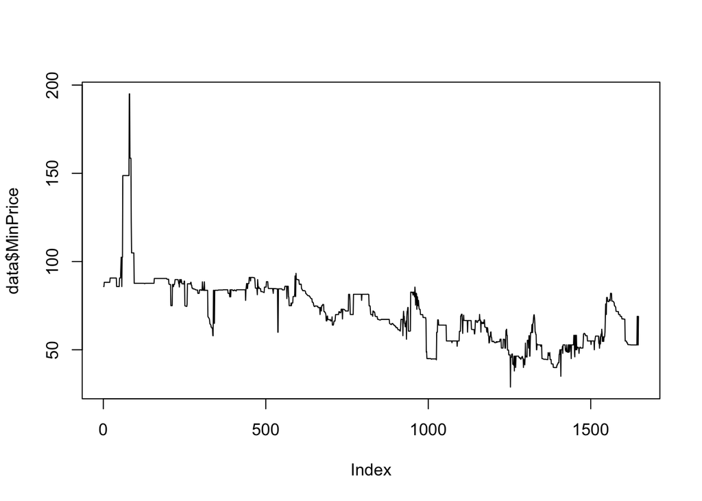

```r
plot(data$MinPrice, type = 'l')
```

### Observation on MinPrice

- In this data set price is not changing much on daily basis, so it can be aggregated to Week level or Month level

```r
# Derive Year and Month attribute
data$Year = as.numeric(format(data$DateRange, format="%Y"))
data$Month = as.numeric(format(data$DateRange, format="%m"))


data = data %>% group_by(Year, Month) %>% summarise("MeanPrice" = mean(MinPrice))

data = data.frame(data)

# Creating sequence Time variable.
data$Time = 1:nrow(data)

data$Month = as.factor(data$Month)
data$Year = NULL

head(data)
```

```
##   Month MeanPrice Time
## 1     5  85.83000    1
## 2     6  89.06333    2
## 3     7  96.44129    3
## 4     8 142.22742    4
## 5     9  88.25417    5
## 6    10  87.66613    6
```

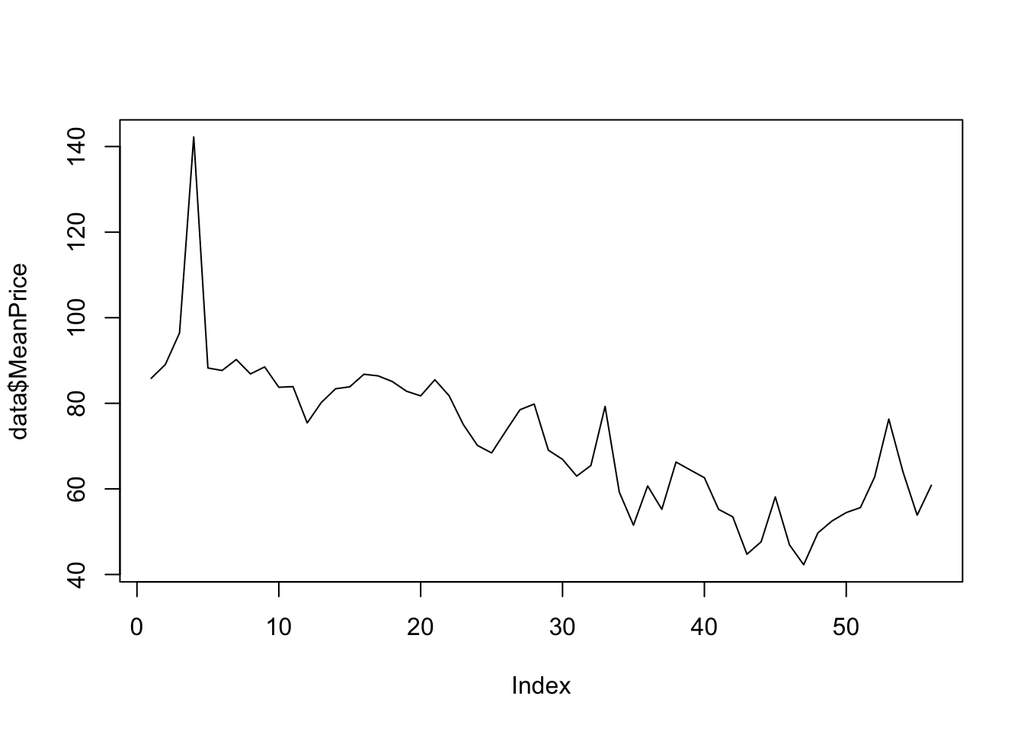

```r
plot(data$MeanPrice, type = 'l')
```

### Splitting of the Dataset into Train and Test

- As this data set is time dependent and sequence is important i.e. no random split.

```r
View(data)
```

```r
train = data[1:45,]
test = data[45:nrow(data),]
rm(data)
```

### Converting data into R time series object

- Our target variable is price and price is aggrigated at month level

```r
train_TS <- ts(train$MeanPrice, frequency = 12, start = c(2009, 4))
train_TS
```

```
##            Jan       Feb       Mar       Apr       May       Jun       Jul
## 2009                                85.83000  89.06333  96.44129 142.22742
## 2010  83.75000  83.89903  75.40967  80.21355  83.39267  83.85597  86.78919
## 2011  81.78536  75.06742  70.15750  68.40629  73.52167  78.49452  79.82468
## 2012  59.26552  51.52387  60.69000  55.22452  66.27367  64.42935  62.61677
##            Aug       Sep       Oct       Nov       Dec
## 2009  88.25417  87.66613  90.22800  86.85968  88.50290
## 2010  86.41067  85.08419  82.82317  81.73871  85.50790
## 2011  69.05000  66.89839  62.98933  65.46919  79.25968
## 2012  55.22667  53.47258  44.73233  47.63968  58.12065
```

```r
test_TS <- ts(test$MeanPrice, frequency = 12, start = c(2013, 1))
test_TS
```

```
##           Jan      Feb      Mar      Apr      May      Jun      Jul
## 2013 58.12065 46.92036 42.27194 49.70667 52.51129 54.46600 55.63645
##           Aug      Sep      Oct      Nov      Dec
## 2013 62.75742 76.30133 63.97484 53.85767 60.84000
```

### Vizualize the time series Data

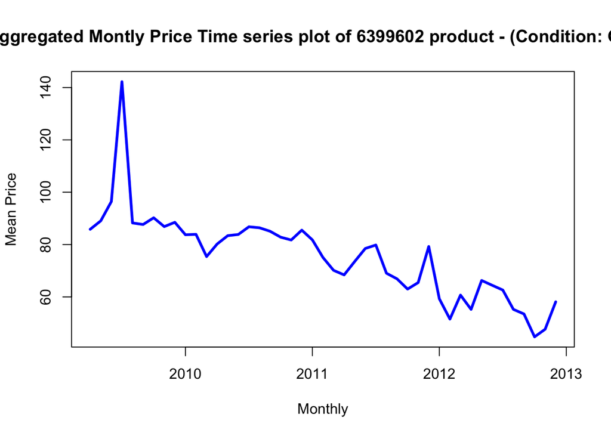

```r
plot(train_TS,
     type="l", lwd=3, col="blue",
     xlab="Monthly", ylab="Mean Price",
     main="Aggregated Montly Price Time series plot of 6399602 product - (Condition: Good)")
```

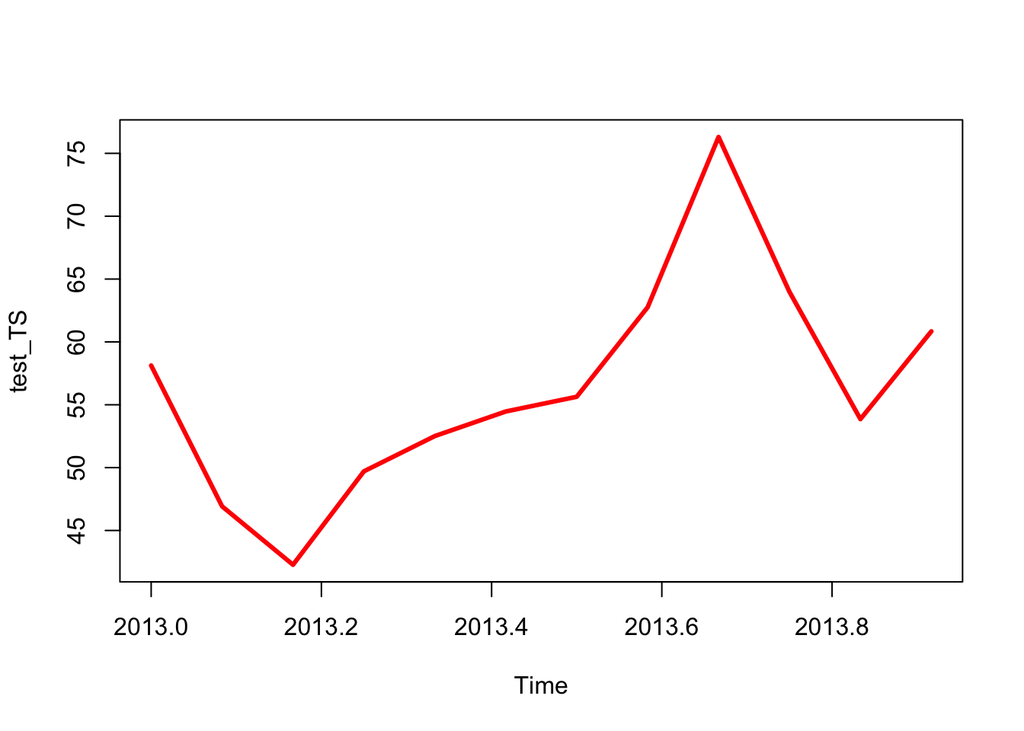

```r
plot(test_TS, col="red", lwd=3)
```

### Decomposed Time Series * Decompose will provide more information on seasonality,trend and randomness

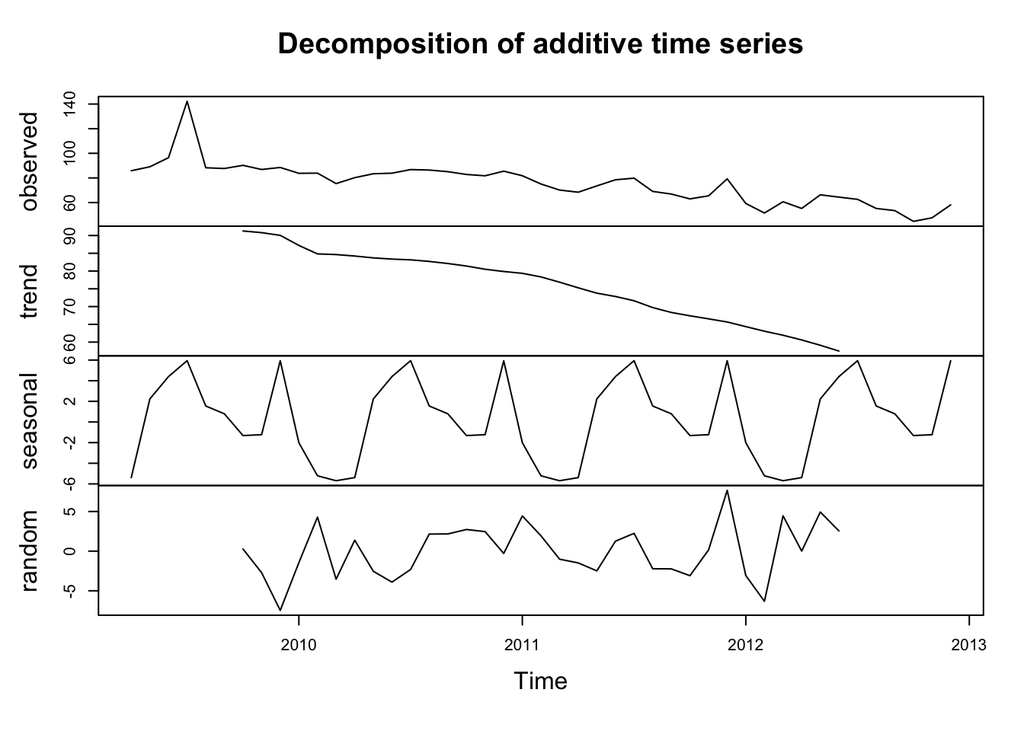

```r
train_Decomposed = decompose(train_TS)
plot(train_Decomposed)
```

```r
rm(train_Decomposed)
```

### ACF, PACF plots

- ACF: n th lag of ACF is the correlation between a day and n days before that.
- PACF: The same as ACF with all intermediate correlations removed.

```r
par(mfrow=c(1,1))
plot(diff(train_TS, lag=1), type="l")
```

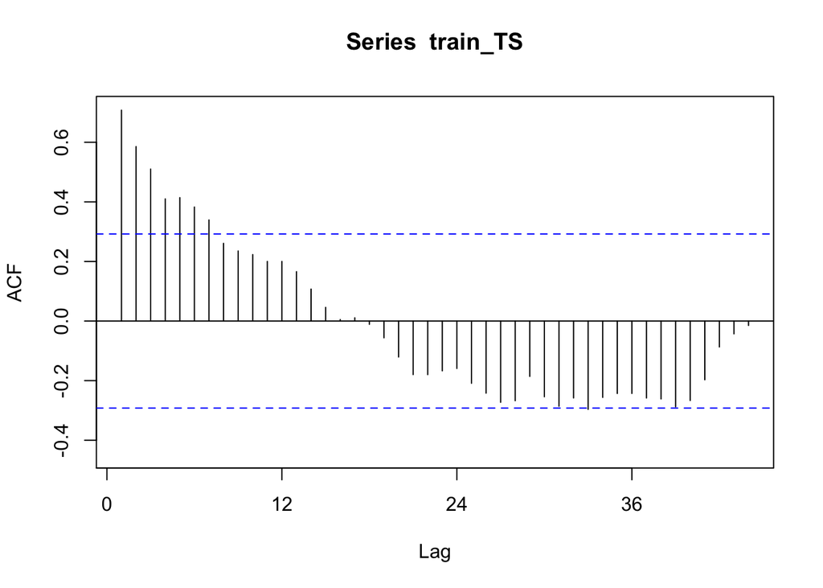

```r
Acf(train_TS,lag=44)
```

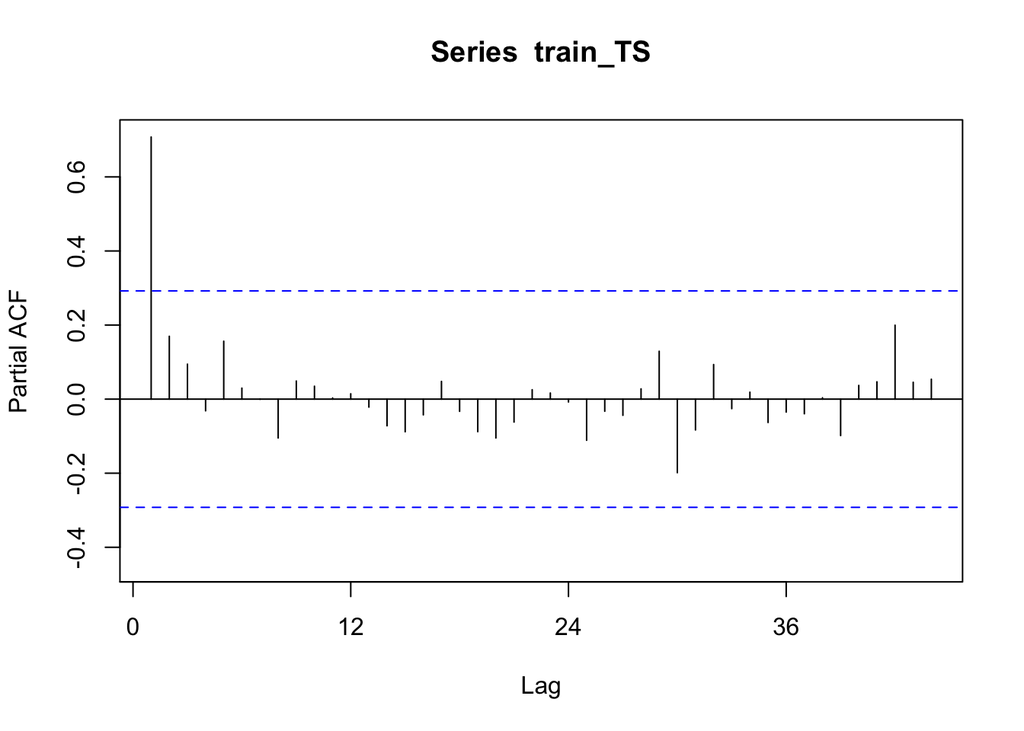

```r
Pacf(train_TS,lag=44)
```

* ACF and PACF –> Idealized Trend, Seasonality and Randomness * Ideal Trend : Decreasing ACF and 1 or 2 lags of PACF * Ideal Seasonality: Cyclicality in ACF and a few lags of PACF with some positive and some negative * Ideal Random : A spike may or may not be present; even if present, magnitude will be small

- Looking at the Y scale in ACF we observe that both trend and seasonality is present.

```r
par(mfrow=c(1,1))

plot(diff(train_TS, lag=1), type="l")
```

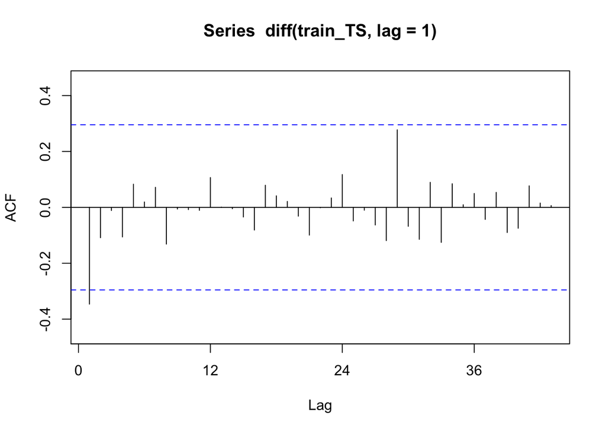

```r
Acf(diff(train_TS,lag=1), lag=43)
```

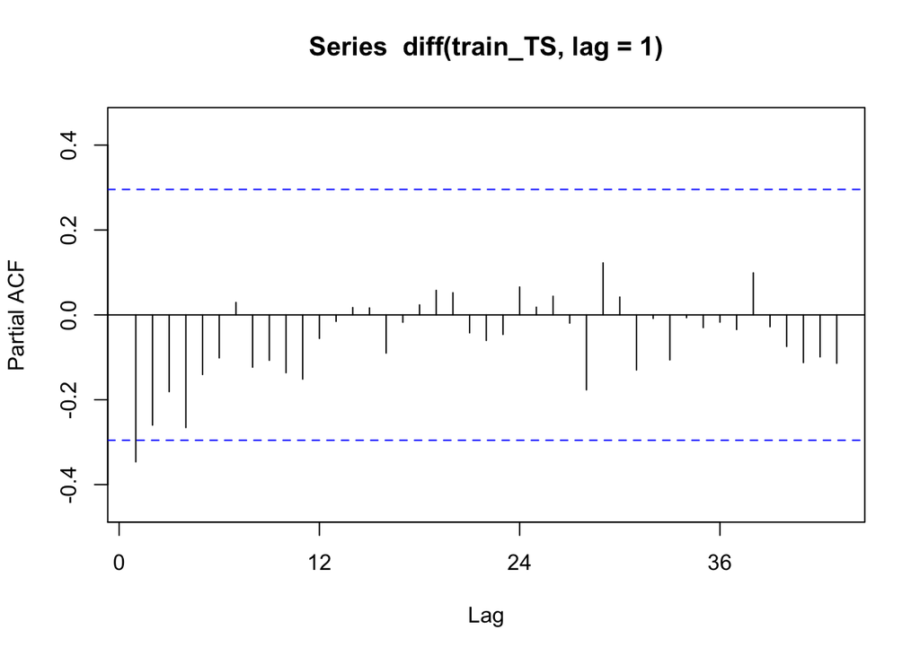

```r
Pacf(diff(train_TS, lag=1),lag=43)
```

### Stationarize by differencing * ndiffs and nsdiffs functions of forecast package can be used to findout the number of differences and seasonal differences, required to stationarize the data

```r
ndiffs(train_TS)
```

```
## [1] 1
```

```r
nsdiffs(train_TS)
```

```
## [1] 0
```

### Modelling the time series using simple moving averages

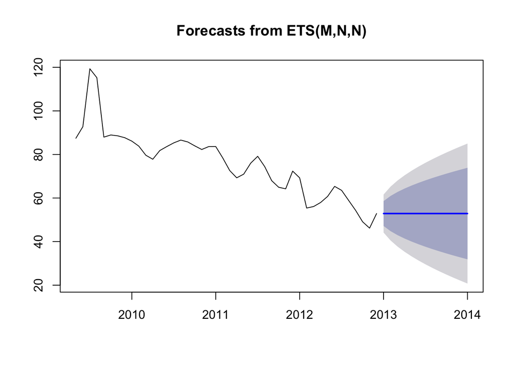

```r
fitsma = SMA(train_TS, n=2)
predsma = forecast(fitsma, h=13)
plot(predsma)
```

### Find error for SMA on both Test and Train data

```r
smaTrainError = regr.eval(train_TS[2:length(train_TS)], fitsma[2:length(train_TS)])
smaTestError = regr.eval(test$MeanPrice, predsma$mean)
smaTrainError
```

```
##         mae         mse        rmse        mape
##  3.43289247 37.95631379  6.16086956  0.04499309
```

```r
smaTestError
```

```
##        mae        mse       rmse       mape
##  7.3556099 88.0734184  9.3847439  0.1245519
```

### Weighted Moving Averages

```r
fitwma = WMA(train_TS, n=2, 1:2)
predwma = forecast(fitwma, h=13)
```

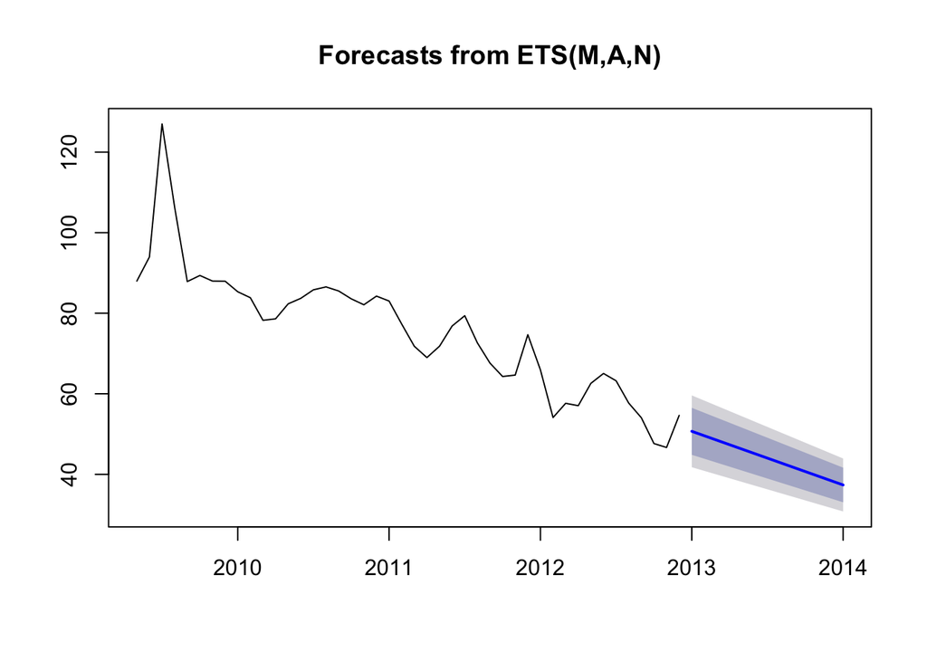

```r
plot(predwma)
```

### Find error for WMA on both Test and Train data

```r
wmaTrainError = regr.eval(train_TS[2:length(train_TS)], fitwma[2:length(train_TS)])
wmaTestError = regr.eval(test$MeanPrice, predwma$mean)
wmaTrainError
```

```
##         mae         mse        rmse        mape
##  2.28859498 16.86947280  4.10724638  0.02999539
```

```r
wmaTestError
```

```
##         mae         mse        rmse        mape
##  15.0742551 302.4268408  17.3904238   0.2500139
```

### Exponential Moving Averages

```r
fitEma = EMA(train_TS, n=2)
predema = forecast(fitEma, h=13)
```

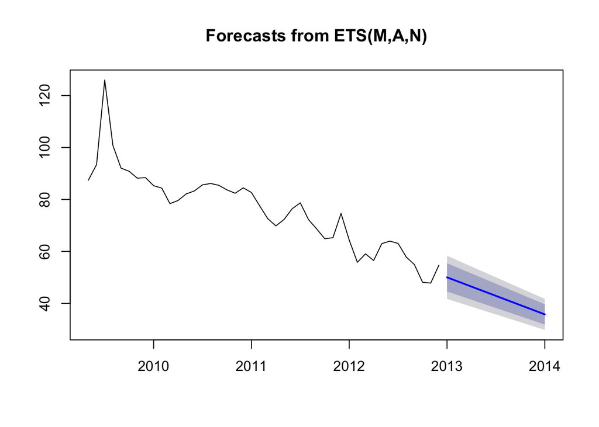

```r
plot(predema)
```

### Find error for EMA on both Test and Train data

```r
emaTrainError = regr.eval(train_TS[2:length(train_TS)], fitEma[2:length(train_TS)])
emaTestError = regr.eval(test$MeanPrice, predema$mean)
emaTrainError
```

```
##         mae         mse        rmse        mape
##  2.33481320 14.24091714  3.77371397  0.03052592
```

```r
emaTestError
```

```
##         mae         mse        rmse        mape
##  16.0378719 340.0250396  18.4397679   0.2657629
```

## Regression on time

- As trend is also present Regression on time will also work.

### Simple Linear Regression

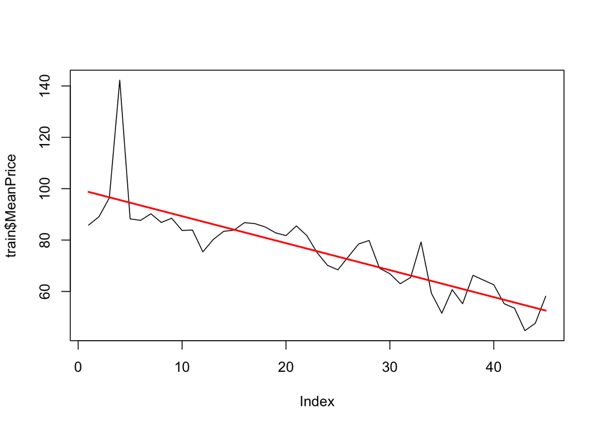

```r
## Simple linear regression
lm1 <- lm(MeanPrice~Time, data = train)

pred_Train = predict(lm1)
pred_Test = predict(lm1, test)

plot(train$MeanPrice, type="l")
points(train$Time, pred_Train, type="l", col="red", lwd=2)
```

### Find error for lm1 on both Test and Train data

```r
lm1TrainError = regr.eval(train$MeanPrice, pred_Train)
lm1TestError = regr.eval(test$MeanPrice,pred_Test)
lm1TrainError
```

```
##         mae         mse        rmse        mape
##  5.85832445 83.65029151  9.14605333  0.07566886
```

```r
lm1TestError
```

```
##        mae        mse       rmse       mape
##  11.799368 215.572722  14.682395   0.195465
```

### Linear Regression (Quadratic)

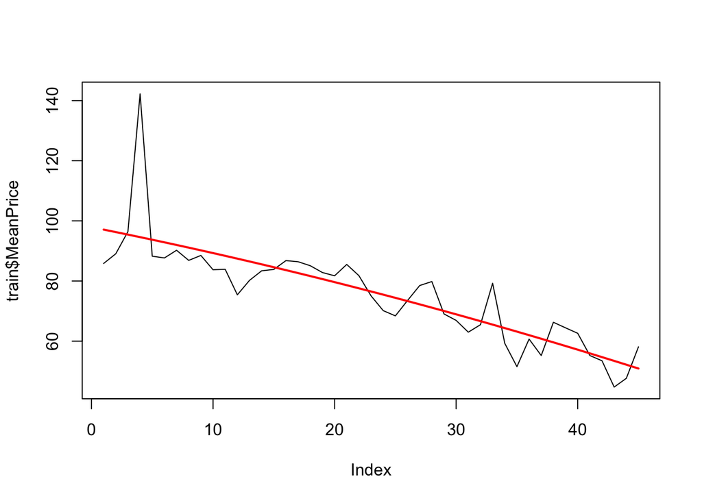

```r
lm2 <- lm(MeanPrice~poly(Time, 2, raw=TRUE), data = train)

pred_Train = predict(lm2)
pred_Test = predict(lm2, test)

plot(train$MeanPrice, type="l")
points(train$Time, pred_Train, type="l", col="red", lwd=2)
```

### Find error for lm2 on both Test and Train data

```r
lm2TrainError = regr.eval(train$MeanPrice, pred_Train)
lm2TestError = regr.eval(test$MeanPrice, pred_Test)
lm2TrainError
```

```
##         mae         mse        rmse        mape
##  5.71883375 83.03129514  9.11215096  0.07368146
```

```r
lm2TestError
```

```
##         mae         mse        rmse        mape
##  14.2604426 303.8028181  17.4299403   0.2354738
```

### Seasonal Linear Regression Model using dummies

```r
str(train)
```

```
## 'data.frame':    45 obs. of  3 variables:
##  $ Month    : Factor w/ 12 levels "1","2","3","4",..: 5 6 7 8 9 10 11 12 1 2 ...
##  $ MeanPrice: num  85.8 89.1 96.4 142.2 88.3 ...
##  $ Time     : int  1 2 3 4 5 6 7 8 9 10 ...
```

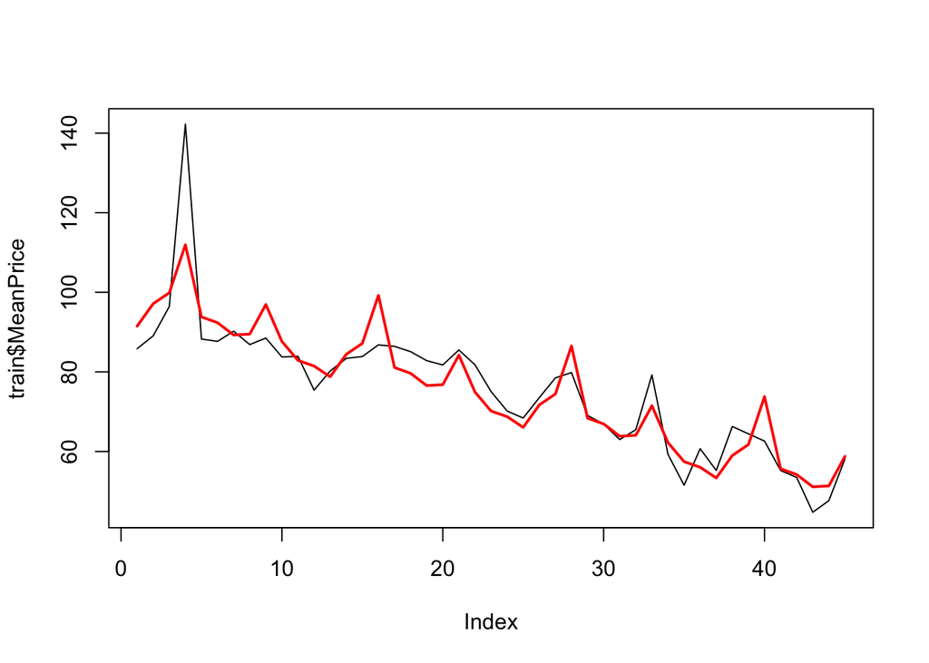

```r
slm1 <- lm(MeanPrice~., data=train)

pred_Train = predict(slm1)
pred_Test = predict(slm1, test)

plot(train$MeanPrice, type="l")
points(train$Time, pred_Train, type="l", col="red", lwd=2)
```

### Find error for slm1 on both Test and Train data

```r
slm1TrainError = regr.eval(train$MeanPrice, pred_Train)
slm1TestError = regr.eval(test$MeanPrice, pred_Test)
slm1TrainError
```

```
##        mae        mse       rmse       mape
##  4.6545729 44.8763590  6.6989819  0.0589463
```

```r
slm1TestError
```

```
##         mae         mse        rmse        mape
##  11.1637131 221.5959489  14.8860992   0.1846722
```

## HoltWinters model

### Build a HoltWinters model

```r
model_HW = HoltWinters(train_TS)
model_HW
```

```
## Holt-Winters exponential smoothing with trend and additive seasonal component.
##
## Call:
## HoltWinters(x = train_TS)
##
## Smoothing parameters:
##  alpha: 0.01021339
##  beta : 1
##  gamma: 0.7341345
##
## Coefficients:
##           [,1]
## a    53.079999
## b    -1.336950
## s1   -5.327354
## s2  -10.957567
## s3   -4.622244
## s4   -7.835155
## s5    2.649866
## s6    3.422604
## s7    3.684104
## s8   -2.722429
## s9   -3.354956
## s10  -9.513489
## s11  -5.759539
## s12   6.125278
```

```r
## If you want a non-seasonal model?
# holtpriceforecast_NoS = HoltWinters(train_TS, gamma = FALSE)
## Model without trend and seasonality?
# holtpriceforecast_NoTS = HoltWinters(train_TS, beta = FALSE, gamma = FALSE)
```

### HoltWinters model - additive and multiplicative models

```r
# Additive Model
model_HW_Add = HoltWinters(train_TS, seasonal="additive")
model_HW_Add
```

```
## Holt-Winters exponential smoothing with trend and additive seasonal component.
##
## Call:
## HoltWinters(x = train_TS, seasonal = "additive")
##
## Smoothing parameters:
##  alpha: 0.01021339
##  beta : 1
##  gamma: 0.7341345
##
## Coefficients:
##           [,1]
## a    53.079999
## b    -1.336950
## s1   -5.327354
## s2  -10.957567
## s3   -4.622244
## s4   -7.835155
## s5    2.649866
## s6    3.422604
## s7    3.684104
## s8   -2.722429
## s9   -3.354956
## s10  -9.513489
## s11  -5.759539
## s12   6.125278
```

```r
# Multiplicative Model
model_HW_Mul = HoltWinters(train_TS, seasonal="multiplicative")
model_HW_Mul
```

```
## Holt-Winters exponential smoothing with trend and multiplicative seasonal component.
##
## Call:
## HoltWinters(x = train_TS, seasonal = "multiplicative")
##
## Smoothing parameters:
##  alpha: 0.01090102
##  beta : 1
##  gamma: 0.8686679
##
## Coefficients:
##           [,1]
## a   52.7110019
## b   -1.3645800
## s1   0.9052012
## s2   0.8104015
## s3   0.9410251
## s4   0.8812674
## s5   1.0623263
## s6   1.0639186
## s7   1.0608120
## s8   0.9543186
## s9   0.9435046
## s10  0.8207350
## s11  0.8906203
## s12  1.1090496
```

- Since you are building the models on monthly data, you will get 12 seasonal components. If you are reading the weekly data, you will get 52 seasonal components

### Prediction on the Train

```r
pred_train_HW = data.frame(model_HW_Mul$fitted)
head(pred_train_HW$xhat)
```

```
## [1] 87.18731 90.18504 89.95190 92.12595 90.97055 88.93126
```

### Prediction on test data

```r
pred_test_HW = forecast(model_HW_Mul, h = 12)
head(pred_test_HW)
```

```
## $method
## [1] "HoltWinters"
##
## $model
## Holt-Winters exponential smoothing with trend and multiplicative seasonal component.
##
## Call:
## HoltWinters(x = train_TS, seasonal = "multiplicative")
##
## Smoothing parameters:
##  alpha: 0.01090102
##  beta : 1
##  gamma: 0.8686679
##
## Coefficients:
##           [,1]
## a   52.7110019
## b   -1.3645800
## s1   0.9052012
## s2   0.8104015
## s3   0.9410251
## s4   0.8812674
## s5   1.0623263
## s6   1.0639186
## s7   1.0608120
## s8   0.9543186
## s9   0.9435046
## s10  0.8207350
## s11  0.8906203
## s12  1.1090496
##
## $level
## [1] 80 95
##
## $mean
##           Jan      Feb      Mar      Apr      May      Jun      Jul
## 2013 46.47884 40.50536 45.75007 41.64225 48.74814 47.36940 45.78352
##           Aug      Sep      Oct      Nov      Dec
## 2013 39.88514 38.14569 32.06218 33.57694 40.29847
##
```

[output cut: 14 more lines]

[output not shown]

```r
pred_test_HW$mean
```

```
##           Jan      Feb      Mar      Apr      May      Jun      Jul
## 2013 46.47884 40.50536 45.75007 41.64225 48.74814 47.36940 45.78352
##           Aug      Sep      Oct      Nov      Dec
## 2013 39.88514 38.14569 32.06218 33.57694 40.29847
```

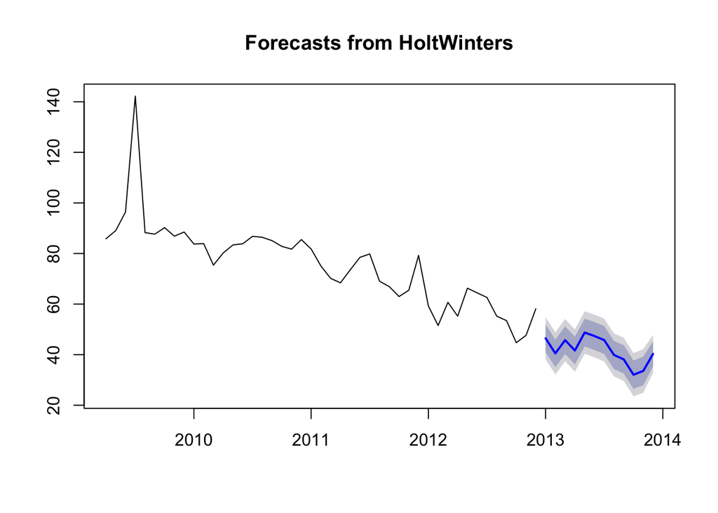

```r
plot(pred_test_HW)
```

### Error metrics

```r
# Make your own function
MAPE = function(predicted, actual){
  mean(abs((actual[1:length(actual)]-predicted[1:length(actual)])/actual[1:length(actual)]))
}

#Or use accuracy() from Forecast package
HW_MAPE = accuracy(test$MeanPrice, pred_test_HW$mean)
HW_MAPE
```

```
##                 ME     RMSE      MAE       MPE     MAPE      ACF1
## Test set -14.75988 18.81067 15.33957 -38.76246 40.02953 0.7192705
##          Theil's U
## Test set  4.178189
```

## ARIMA Models

### Manual ARIMA Model

- The order of the model p is determined based on the number beyond which PACF terms are zero.
- The number of terms, q, is determined from the ACF plot. Its the m aximum lag beyond which the ACF is 0

### ACF and PACF Plots

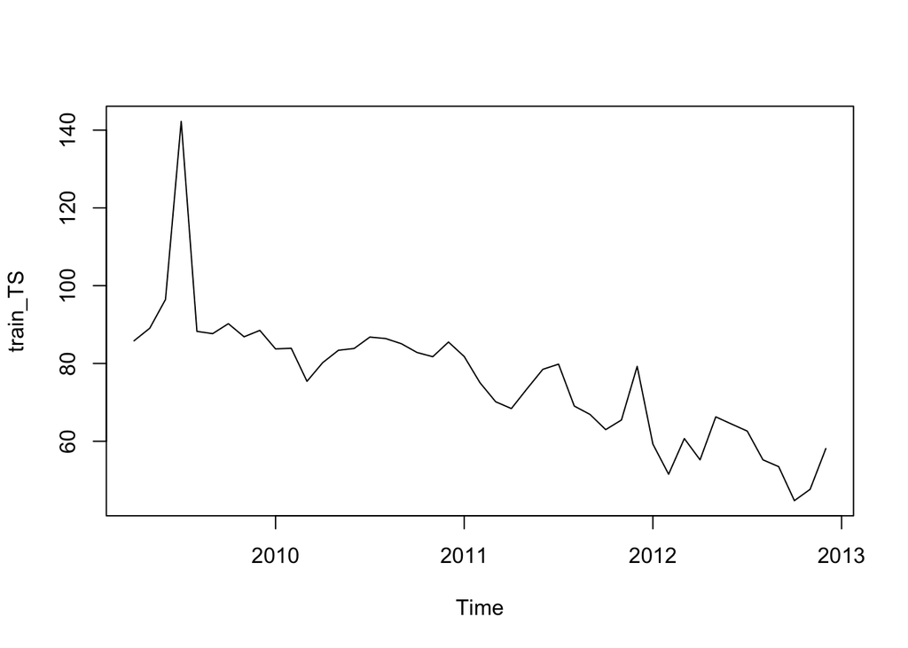

```r
par(mfrow=c(1,1))
plot(train_TS)
```

```r
plot(diff(train_TS, lag=1), type="l")
```

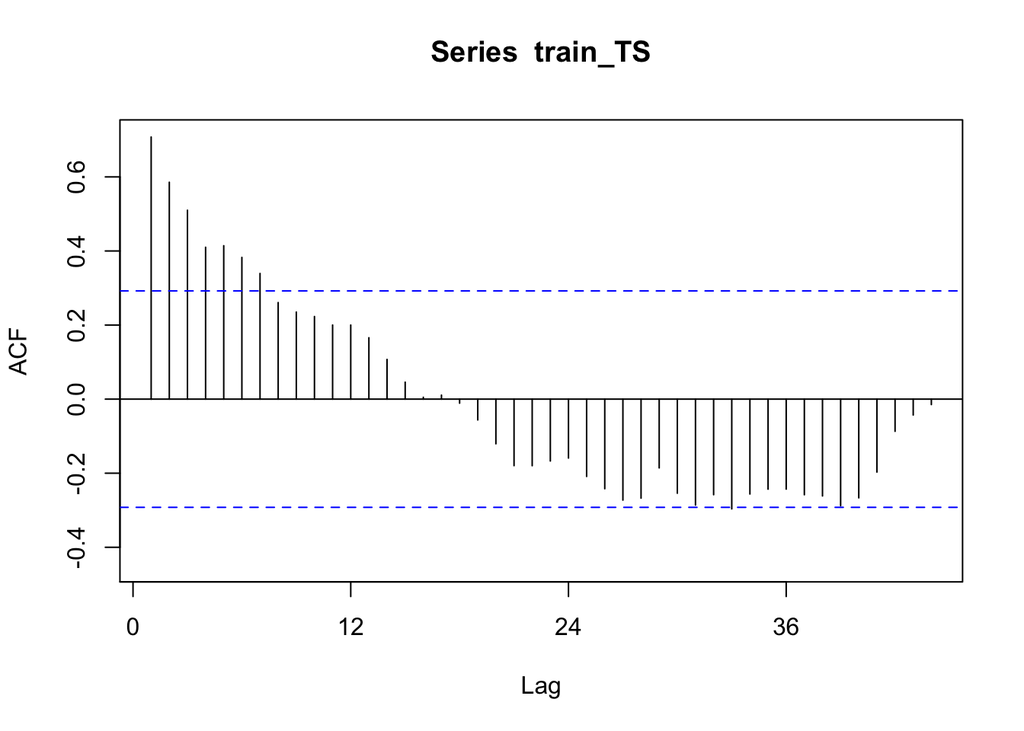

```r
Acf(train_TS,lag=44)
```

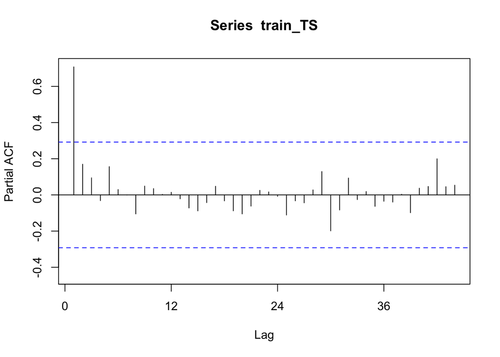

```r
Pacf(train_TS,lag=44)
```

### Stationarize by differencing

- d is the number of non-seasonal differences
- D is the number of seasonal differences

```r
ndiffs(train_TS)
```

```
## [1] 1
```

```r
nsdiffs(train_TS)
```

```
## [1] 0
```

- Lets do a seasonal differencing first and then plot Acf and Pacf

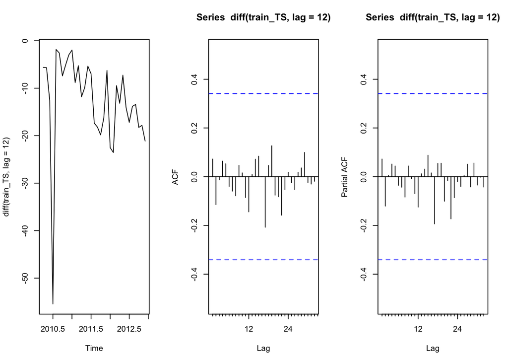

```r
par(mfrow=c(1,3))

plot(diff(train_TS, lag=12),type="l")

Acf(diff(train_TS,lag = 12),lag=40)
Pacf(diff(train_TS,lag = 12),lag=40)
```

- Lets do a seasonal differencing first and then non seasonal difference,plot Acf and Pacf

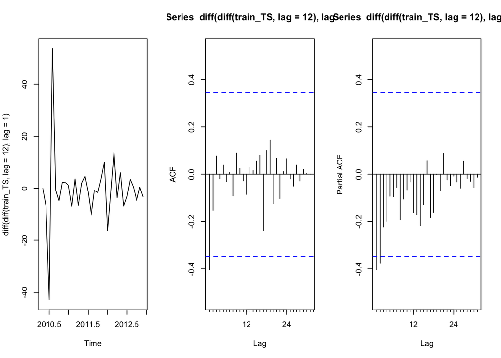

```r
par(mfrow=c(1,3))

plot(diff(diff(train_TS, lag=12), lag=1),type="l")

Acf(diff(diff(train_TS, lag=12), lag=1),lag=40)
Pacf(diff(diff(train_TS, lag=12), lag=1),lag=40)
```

- ARIMA model ARIMA(0,1,0)(0,1,0)

```r
ARIMA_1 = Arima(train_TS, c(0,1,0), c(0,1,0))
summary(ARIMA_1)
```

```
## Series: train_TS
## ARIMA(0,1,0)(0,1,0)[12]
##
## sigma^2 estimated as 180:  log likelihood=-128.5
## AIC=258.99   AICc=259.12   BIC=260.46
##
## Training set error measures:
##                      ME     RMSE      MAE        MPE     MAPE      MASE
## Training set -0.3510333 11.31459 5.107426 -0.7249835 6.955954 0.4023362
##                    ACF1
## Training set -0.4036554
```

### Check the acf and pacf plots

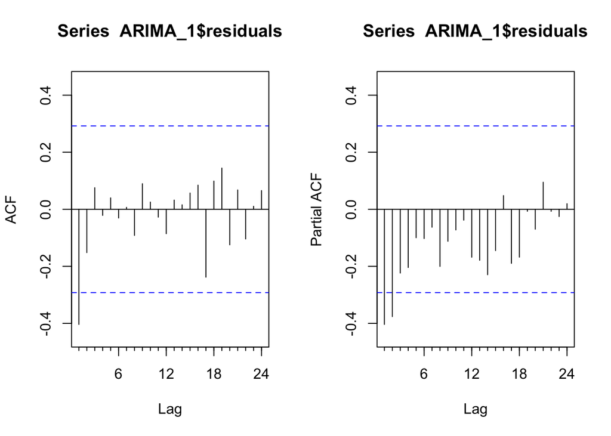

```r
par(mfrow = c(1,2))
Acf(ARIMA_1$residuals)
Pacf(ARIMA_1$residuals)
```

```r
ARIMA_1 = Arima(train_TS, c(0,1,2), c(0,1,0))    # Try different models.
summary(ARIMA_1)
```

```
## Series: train_TS
## ARIMA(0,1,2)(0,1,0)[12]
##
## Coefficients:
##           ma1      ma2
##       -0.8345  -0.1075
## s.e.   0.2074   0.2012
##
## sigma^2 estimated as 108.9:  log likelihood=-120.45
## AIC=246.91   AICc=247.77   BIC=251.31
##
## Training set error measures:
##                    ME     RMSE      MAE       MPE     MAPE      MASE
## Training set -1.03087 8.520793 4.767822 -2.028251 6.697229 0.3755839
##                     ACF1
## Training set -0.02144976
```

### Check the acf and pacf plots

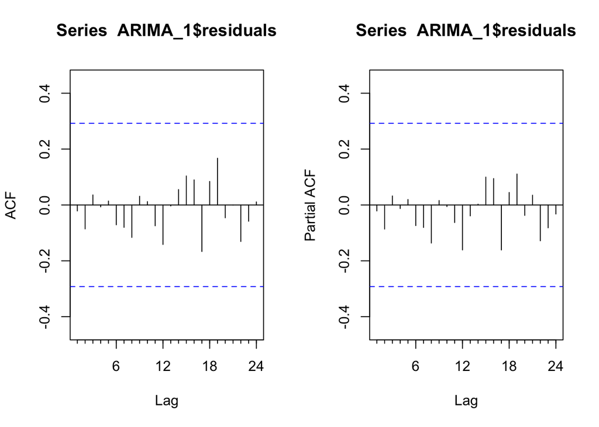

```r
par(mfrow = c(1,2))
Acf(ARIMA_1$residuals)
Pacf(ARIMA_1$residuals)
```

### Box-Lyung Test

- Null Hypothesis : Error are not correlated
- Alternative Hypothesis: Error are correlated

```r
Box.test(ARIMA_1$residuals, type="Ljung-Box", lag = 24)
```

```
##
##  Box-Ljung test
##
## data:  ARIMA_1$residuals
## X-squared = 12.136, df = 24, p-value = 0.9783
```

```r
#Null Hypothesis : No serial correlation upto 24 lags

# No significant spikes
```

## Predictions

### Prediction on the Train

```r
pred_Train = fitted(ARIMA_1)
pred_Train
```

```
##            Jan       Feb       Mar       Apr       May       Jun       Jul
## 2009                                85.78045  89.03867  96.41891 142.17036
## 2010  83.75595  83.90430  75.47919  80.54825  83.43501  89.75589 128.70500
## 2011  74.06593  74.92570  65.75315  71.31594  73.49384  74.32813  78.03157
## 2012  71.38222  61.94401  56.56702  56.62683  61.08191  67.07538  67.38851
##            Aug       Sep       Oct       Nov       Dec
## 2009  88.25747  87.66942  90.22843  86.86322  88.50449
## 2010  65.40858  74.78367  77.90916  74.87046  77.72480
## 2011  77.44034  74.36841  71.61626  69.79135  73.76747
## 2012  56.09086  54.30345  50.33583  51.95723  65.61344
```

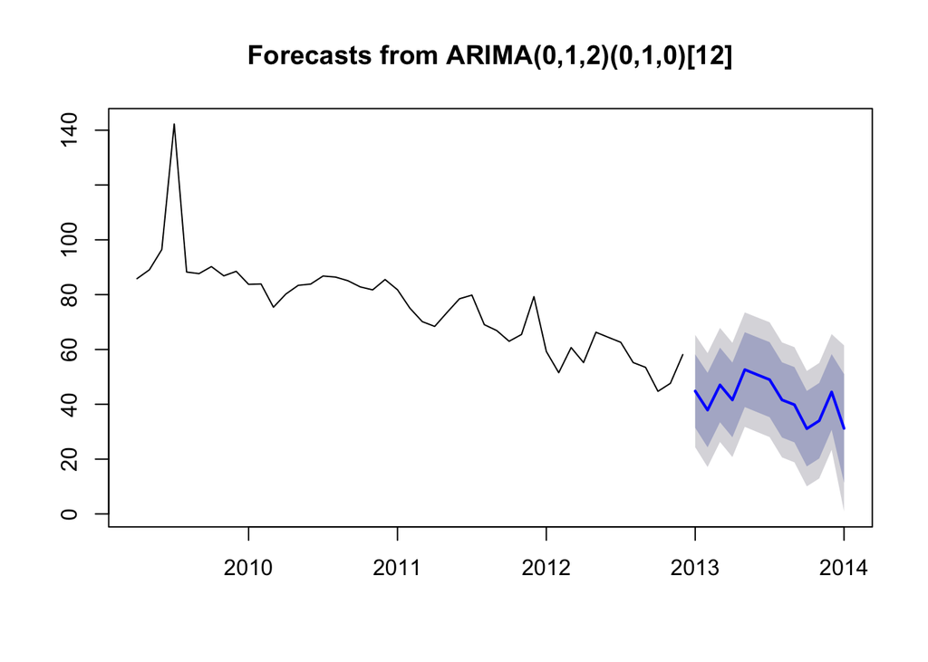

```r
pred_Test = forecast(ARIMA_1, h = 13)
plot(pred_Test)
```

### Find error for Arima_1 on both Test and Train data

```r
regr.eval(train$MeanPrice, pred_Train)
```

```
##         mae         mse        rmse        mape
##  4.76782207 72.60391319  8.52079299  0.06697229
```

```r
regr.eval(test$MeanPrice, data.frame(pred_Test)$Point.Forecast)
```

```
##        mae        mse       rmse       mape
##  16.607540 387.395731  19.682371   0.276367
```

### Auto Arima

```r
ARIMA_auto = auto.arima(train_TS)
summary(ARIMA_auto)
```

```
## Series: train_TS
## ARIMA(3,1,0)(1,0,0)[12]
##
## Coefficients:
##           ar1      ar2      ar3    sar1
##       -0.6386  -0.5328  -0.3881  0.4917
## s.e.   0.1564   0.1725   0.1856  0.1875
##
## sigma^2 estimated as 105.4:  log likelihood=-164.94
## AIC=339.88   AICc=341.46   BIC=348.8
##
## Training set error measures:
##                     ME     RMSE      MAE       MPE     MAPE      MASE
## Training set -1.334984 9.678384 6.906273 -2.912888 8.972374 0.5440398
##                     ACF1
## Training set -0.03808668
```

### Forecast on autoARIMA model

```r
pred_Train = fitted(ARIMA_auto)
pred_Train
```

```
##            Jan       Feb       Mar       Apr       May       Jun       Jul
## 2009                                85.74417  86.82957  90.03132 101.96961
## 2010  86.91525  87.78112  89.26076  75.71379  79.71055  83.16911 102.19751
## 2011  82.34171  80.94389  74.81905  77.14536  75.62372  73.95807  76.61037
## 2012  69.28673  60.03225  56.98870  61.84799  56.23281  61.22801  65.06273
##            Aug       Sep       Oct       Nov       Dec
## 2009 104.69476  94.21385  98.39205 108.10476  86.08603
## 2010  73.82333  81.07603  80.66756  73.81559  84.45992
## 2011  75.80344  73.37767  72.42905  69.15067  67.47063
## 2012  57.86746  58.48373  54.06714  51.48858  57.24514
```

```r
pred_Test = forecast(ARIMA_auto, h=13)
pred_Test
```

```
##          Point Forecast    Lo 80    Hi 80     Lo 95    Hi 95
## Jan 2013       47.67352 34.51779 60.82926 27.553560 67.79349
## Feb 2013       41.63397 27.64539 55.62255 20.240284 63.02766
## Mar 2013       46.45909 32.12890 60.78929 24.542948 68.37523
## Apr 2013       44.99745 30.23873 59.75618 22.425927 67.56898
## May 2013       50.34458 33.83515 66.85400 25.095591 75.59357
## Jun 2013       48.71589 31.36345 66.06834 22.177627 75.25416
## Jul 2013       47.85557 29.94615 65.76500 20.465471 75.24567
## Aug 2013       44.62003 26.12737 63.11269 16.337943 72.90212
## Sep 2013       43.76704 24.39254 63.14154 14.136302 73.39778
## Oct 2013       39.23943 19.15553 59.32333  8.523752 69.95511
## Nov 2013       40.65636 19.98094 61.33177  9.036035 72.27668
## Dec 2013       45.93669 24.67495 67.19843 13.419663 78.45372
## Jan 2014       40.81490 16.50386 65.12594  3.634376 77.99543
```

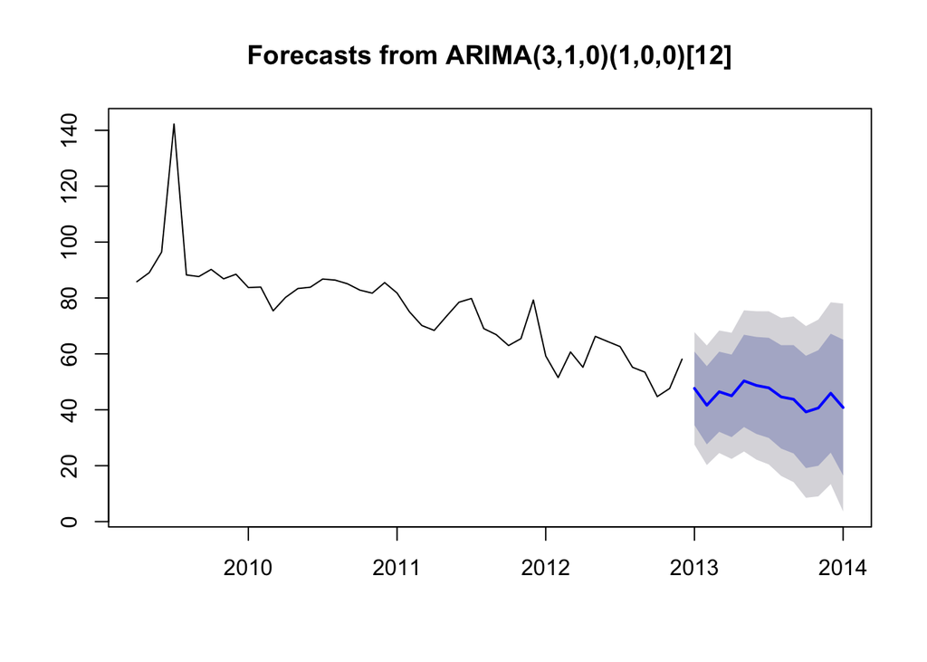

```r
plot(pred_Test)
```

### Check the acf and pacf plots

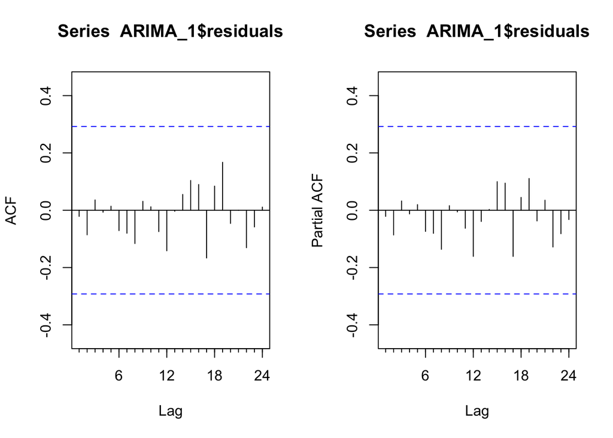

```r
par(mfrow = c(1,2))
Acf(ARIMA_1$residuals)
Pacf(ARIMA_1$residuals)
```

### Find error for Arima_1 on both Test and Train data

```r
regr.eval(train$MeanPrice, pred_Train)
```

```
##         mae         mse        rmse        mape
##  6.90627290 93.67111341  9.67838382  0.08972374
```

```r
regr.eval(test$MeanPrice, data.frame(pred_Test)$Point.Forecast)
```

```
##         mae         mse        rmse        mape
##  13.4287521 247.5212550  15.7328082   0.2218973
```